# More on linear models

8 April 2020

## Goals for today

- Understand how to represent a linear model with matrix notation
- Understand the concept, assumptions & practice of least squares estimation for linear models
- Understand the concept of identifiability

## Linear models in matrix form

### Simple regression

\[ y_i = \alpha + \beta x_{i} + e_i \\ \Downarrow^{*} \\ y_i = \beta_0 + \beta_1 x_{i} + e_i \]

The \(i\) subscript indicates one of a total \(N\) observations

\(^*\)The reason for this notation switch will become clear later

## Linear models in matrix form

### Simple regression

Let’s make this general statement more specific

\[ y_i = \beta_0 + \beta_1 x_{i} + e_i \\ \Downarrow \\ y_1 = \beta_0 + \beta_1 x_{1} + e_1 \\ y_2 = \beta_0 + \beta_1 x_{2} + e_2 \\ \vdots \\ y_N = \beta_0 + \beta_1 x_{N} + e_N \\ \]

## Linear models in matrix form

### Simple regression

Let’s now make the implicit “1” multiplier on \(\beta_0\) explicit

\[ y_1 = \beta_0 \underline{1} + \beta_1 x_{1} + e_1 \\ y_2 = \beta_0 \underline{1} + \beta_1 x_{2} + e_2 \\ \vdots \\ y_N = \beta_0 \underline{1} + \beta_1 x_{N} + e_N \\ \]

## Linear models in matrix form

### Simple regression

Let’s next gather the common terms into column vectors

\[ y_1 = \beta_0 1 + \beta_1 x_{1} + e_1 \\ y_2 = \beta_0 1 + \beta_1 x_{2} + e_2 \\ \vdots \\ y_N = \beta_0 1 + \beta_1 x_{N} + e_N \\ \]

## Linear models in matrix form

### Simple regression

Maybe something like this?

\[ \begin{bmatrix} y_1 \\ y_2 \\ \vdots \\ y_N \end{bmatrix} = \begin{bmatrix} \beta_0 \\ \beta_0 \\ \vdots \\ \beta_0 \end{bmatrix} \begin{bmatrix} 1 \\ 1 \\ \vdots \\ 1 \end{bmatrix} + \begin{bmatrix} \beta_1 \\ \beta_1 \\ \vdots \\ \beta_1 \end{bmatrix} \begin{bmatrix} x_1 \\ x_2 \\ \vdots \\ x_N \end{bmatrix} + \begin{bmatrix} e_1 \\ e_2 \\ \vdots \\ e_N \end{bmatrix} \]

## An aside on linear algebra

We refer to the dimensions of matrices in a row-by-column manner

\([rows \times columns]\)

## An aside on linear algebra

When adding matrices, the dimensions must match

\([m \times n] + [m \times n]\) **✓**

\([m \times n] + [m \times p]\) **X**

## An aside on linear algebra

When multiplying 2 matrices, the inner dimensions must match

\([m \times \underline{n}] [\underline{n} \times p]\) **✓**

\([m \times \underline{n}] [\underline{p} \times n]\) **X**

## An aside on linear algebra

When multiplying 2 matrices, the dimensions are  
[rows-of-first \(\times\) columns-of-second]

\([\underline{m} \times n] [n \times \underline{p}] = [m \times p]\)

## Linear models in matrix form

### Simple regression

Let’s check the dimensions

\[ \begin{bmatrix} y_1 \\ y_2 \\ \vdots \\ y_N \end{bmatrix} = \begin{bmatrix} \beta_0 \\ \beta_0 \\ \vdots \\ \beta_0 \end{bmatrix} \begin{bmatrix} 1 \\ 1 \\ \vdots \\ 1 \end{bmatrix} + \begin{bmatrix} \beta_1 \\ \beta_1 \\ \vdots \\ \beta_1 \end{bmatrix} \begin{bmatrix} x_1 \\ x_2 \\ \vdots \\ x_N \end{bmatrix} + \begin{bmatrix} e_1 \\ e_2 \\ \vdots \\ e_N \end{bmatrix} \]

## Linear models in matrix form

### Simple regression

Let’s check the dimensions

\[ \begin{bmatrix} y_1 \\ y_2 \\ \vdots \\ y_N \end{bmatrix} = \begin{bmatrix} \beta_0 \\ \beta_0 \\ \vdots \\ \beta_0 \end{bmatrix} \begin{bmatrix} 1 \\ 1 \\ \vdots \\ 1 \end{bmatrix} + \begin{bmatrix} \beta_1 \\ \beta_1 \\ \vdots \\ \beta_1 \end{bmatrix} \begin{bmatrix} x_1 \\ x_2 \\ \vdots \\ x_N \end{bmatrix} + \begin{bmatrix} e_1 \\ e_2 \\ \vdots \\ e_N \end{bmatrix} \]

\[ [N \times 1] = \underbrace{[N \times 1] [N \times 1]}_{\text{OOPS!}} + \underbrace{[N \times 1] [N \times 1]}_{\text{OOPS!}} + [N \times 1] \]

## An aside on linear algebra

When multiplying a scalar times a vector/matrix, it’s just element-wise

\[ a \begin{bmatrix} X \\ Y \\ Z \end{bmatrix} = \begin{bmatrix} aX \\ aY \\ aZ \end{bmatrix} \]

## Linear models in matrix form

### Simple regression

So this looks better

\[ \begin{bmatrix} y_1 \\ y_2 \\ \vdots \\ y_N \end{bmatrix} = \beta_0 \begin{bmatrix} 1 \\ 1 \\ \vdots \\ 1 \end{bmatrix} + \beta_1 \begin{bmatrix} x_1 \\ x_2 \\ \vdots \\ x_N \end{bmatrix} + \begin{bmatrix} e_1 \\ e_2 \\ \vdots \\ e_N \end{bmatrix} \]

\[ [N \times 1] = [N \times 1] + [N \times 1] + [N \times 1] \]

## Linear models in matrix form

### Simple regression

This is nice, but can we make \(\beta_0\) and \(\beta_1\) more compact?

\[ \begin{bmatrix} y_1 \\ y_2 \\ \vdots \\ y_N \end{bmatrix} = \beta_0 \begin{bmatrix} 1 \\ 1 \\ \vdots \\ 1 \end{bmatrix} + \beta_1 \begin{bmatrix} x_1 \\ x_2 \\ \vdots \\ x_N \end{bmatrix} + \begin{bmatrix} e_1 \\ e_2 \\ \vdots \\ e_N \end{bmatrix} \]

## Linear models in matrix form

### Simple regression

What if we move \(\beta_0\) & \(\beta_1\) to the other side of the predictors…

\[ \begin{bmatrix} y_1 \\ y_2 \\ \vdots \\ y_N \end{bmatrix} = \begin{bmatrix} 1 \\ 1 \\ \vdots \\ 1 \end{bmatrix} \beta_0 + \begin{bmatrix} x_1 \\ x_2 \\ \vdots \\ x_N \end{bmatrix} \beta_1 + \begin{bmatrix} e_1 \\ e_2 \\ \vdots \\ e_N \end{bmatrix} \]

## Linear models in matrix form

### Simple regression

…and group the predictors and parameters into matrices

\[ \begin{bmatrix} y_1 \\ y_2 \\ \vdots \\ y_N \end{bmatrix} = \begin{bmatrix} 1 & x_1 \\ 1 & x_2 \\ \vdots & \vdots \\ 1 & x_N \end{bmatrix} \begin{bmatrix} \beta_0 & \beta_1 \end{bmatrix} + \begin{bmatrix} e_1 \\ e_2 \\ \vdots \\ e_N \end{bmatrix} \]

## Linear models in matrix form

### Simple regression

Let’s check the dimensions

\[ \begin{bmatrix} y_1 \\ y_2 \\ \vdots \\ y_N \end{bmatrix} = \begin{bmatrix} 1 & x_1 \\ 1 & x_2 \\ \vdots & \vdots \\ 1 & x_N \end{bmatrix} \begin{bmatrix} \beta_0 & \beta_1 \end{bmatrix} + \begin{bmatrix} e_1 \\ e_2 \\ \vdots \\ e_N \end{bmatrix} \]

\[ [N \times 1] = \underbrace{[N \times 2] [1 \times 2]}_{\text{OOPS!}} + [N \times 1] \]

## An aside on linear algebra

Matrix multiplication works on a row-times-column manner

\[ \begin{aligned} \begin{bmatrix} a & b \\ c & d \end{bmatrix} \begin{bmatrix} X \\ Y \end{bmatrix} &= \begin{bmatrix} aX + bY \\ cX + dY \end{bmatrix} \\ ~ \\ [2 \times 2] [2 \times 1] &= [2 \times 1] \end{aligned} \]

## Linear models in matrix form

### Simple regression

Let’s transpose the parameter vector \([\beta_0 ~~ \beta_1]^{\top}\)

\[ \begin{bmatrix} y_1 \\ y_2 \\ \vdots \\ y_N \end{bmatrix} = \begin{bmatrix} 1 & x_1 \\ 1 & x_2 \\ \vdots & \vdots \\ 1 & x_N \end{bmatrix} \begin{bmatrix} \beta_0 \\ \beta_1 \end{bmatrix} + \begin{bmatrix} e_1 \\ e_2 \\ \vdots \\ e_N \end{bmatrix} \]

## Linear models in matrix form

### Simple regression

and check the dimensions

\[ \begin{bmatrix} y_1 \\ y_2 \\ \vdots \\ y_N \end{bmatrix} = \begin{bmatrix} 1 & x_1 \\ 1 & x_2 \\ \vdots & \vdots \\ 1 & x_N \end{bmatrix} \begin{bmatrix} \beta_0 \\ \beta_1 \end{bmatrix} + \begin{bmatrix} e_1 \\ e_2 \\ \vdots \\ e_N \end{bmatrix} \]

\[ \begin{align} [N \times 1] &= [N \times 2] [2 \times 1] + [N \times 1] \\ &= [N \times 1] + [N \times 1] \\ &= [N \times 1] \end{align} \]

## Linear models in matrix form

### Simple regression

Lastly, we can write the model in a more compact notation

\[ \begin{bmatrix} y_1 \\ y_2 \\ \vdots \\ y_N \end{bmatrix} = \begin{bmatrix} 1 & x_1 \\ 1 & x_2 \\ \vdots & \vdots \\ 1 & x_N \end{bmatrix} \begin{bmatrix} \beta_0 \\ \beta_1 \end{bmatrix} + \begin{bmatrix} e_1 \\ e_2 \\ \vdots \\ e_N \end{bmatrix} \\ \Downarrow \\ \mathbf{y} = \mathbf{X} \boldsymbol{\beta} + \mathbf{e} \]

## Linear models in matrix form

### Multiple regression

The matrix form is generalizaable to multiple predictors

\[ \begin{bmatrix} y_1 \\ y_2 \\ \vdots \\ y_N \end{bmatrix} = \begin{bmatrix} 1 & x_{1,1} & x_{2,1} \\ 1 & x_{1,2} & x_{2,2} \\ \vdots & \vdots \\ 1 & x_{1,N} & x_{2,N} \end{bmatrix} \begin{bmatrix} \beta_0 \\ \beta_1 \\ \beta_2 \end{bmatrix} + \begin{bmatrix} e_1 \\ e_2 \\ \vdots \\ e_N \end{bmatrix} \\ \Downarrow \\ \mathbf{y} = \mathbf{X} \boldsymbol{\beta} + \mathbf{e} \]

## QUESTIONS?

## Ordinary least squares

In general, we have something like

\[ DATA = MODEL + ERRORS \]

Ideally we have something like

\[ DATA \approx MODEL \]

and hence

\[ ERRORS \approx 0 \]

## Ordinary least squares

From this it follows that

\[ \text{Var}(DATA) = \text{Var}(MODEL) + \text{Var}(ERRORS) \]

Our hope is that

\[ \text{Var}(DATA) \approx \text{Var}(MODEL) \]

and hence

\[ \text{Var}(ERRORS) \approx 0 \]

## Ordinary least squares

Our model for the data is

\[ y_i = f(\text{predictors}_i) + e_i \]

and our estimate of \(y\) is

\[ \hat{y}_i = f(\text{predictors}_i) \]

and therefore the errors (residuals) are given by

\[ e_i = y_i - \hat{y}_i \]

In general, we want to minimize each of the \(e_i\)

## Ordinary least squares

Specifically, we want to minimize the sum of their squares

\[ \min \sum_{i = 1}^{N}e_i^2 ~ \Rightarrow ~ \min \sum_{i = 1}^{N}(y_i - \hat{y}_i)^2 \]

## Ordinary least squares

For our linear regression model, we have

\[ \min \sum_{i = 1}^{N}(y_i - \hat{y}_i)^2 \\ \Downarrow \\ \min \sum_{i = 1}^{N} \left(y_i - (\hat{\beta}_0 + \hat{\beta}_1 x_i) \right)^2 \]

## An aside on linear algebra

Recall that matrix multiplication works in a row-by-column manner

\[ \begin{bmatrix} a & b \\ c & d \end{bmatrix} \begin{bmatrix} X \\ Y \end{bmatrix} = \begin{bmatrix} aX + bY \\ cX + dY \end{bmatrix} \]

## An aside on linear algebra

If \(\mathbf{v}\) is an \([n \times 1]\) column vector & \(\mathbf{v}^{\top}\) is its \([1 \times n]\) transpose,

multiplying \(\mathbf{v}^{\top} \mathbf{v}\) gives the sum of the squared values in \(\mathbf{v}\)

\[ \begin{aligned} \begin{bmatrix} a & b & c \end{bmatrix} \begin{bmatrix} a \\ b \\ c \end{bmatrix} &= \begin{bmatrix} a^2 + b^2 + c^2 \end{bmatrix} \\ ~ \\ [1 \times n] [n \times 1] &= [1 \times 1] \end{aligned} \]

## Ordinary least squares

Writing our linear regression model in matrix form, we have

\[ \mathbf{y} = \mathbf{X} \hat{\boldsymbol{\beta}} + \mathbf{e} \\ \Downarrow \\ \mathbf{e} = \mathbf{y} - \mathbf{X} \hat{\boldsymbol{\beta}} \]

so the sum of squared errors is

\[ \mathbf{e}^{\top} \mathbf{e} = (\mathbf{y} - \mathbf{X} \hat{\boldsymbol{\beta}})^{\top} (\mathbf{y} - \mathbf{X} \hat{\boldsymbol{\beta}}) \]

## Finding the minimum

For example, at what value of \(x\) does this parabola reach its minimum?

\[ y = 2 x^2 - 3 x + 1 \]

Recall from calculus that we

1. differentiate \(y\) with respect to \(x\)
2. set the result to 0
3. solve for \(x\)

## Finding the minimum

For example, at what value of \(x\) does this parabola reach its minimum?

\[ y = 2 x^2 - 3 x + 1 \\ \Downarrow \\ \frac{dy}{dx} = 4 x - 3 \\ \Downarrow \\ 4 x - 3 = 0 \\ x = \tfrac{3}{4} \]

## Ordinary least squares

We want to minimize the sum of squared errors

\[ \begin{align} \mathbf{e}^{\top} \mathbf{e} &= (\mathbf{y} - \mathbf{X} \hat{\boldsymbol{\beta}})^{\top} (\mathbf{y} - \mathbf{X} \hat{\boldsymbol{\beta}}) \\ &= \mathbf{y}^{\top} \mathbf{y} - \mathbf{y}^{\top} \mathbf{X} \hat{\boldsymbol{\beta}} - \hat{\boldsymbol{\beta}}^{\top} \mathbf{X}^{\top} \mathbf{y} + \hat{\boldsymbol{\beta}}^{\top} \mathbf{X}^{\top} \mathbf{X} \hat{\boldsymbol{\beta}} \end{align} \]

and so we want

\[ \frac{\partial}{\partial \hat{\boldsymbol{\beta}}} \mathbf{y}^{\top} \mathbf{y} - \mathbf{y}^{\top} \mathbf{X} \hat{\boldsymbol{\beta}} - \hat{\boldsymbol{\beta}}^{\top} \mathbf{X}^{\top} \mathbf{y} + \hat{\boldsymbol{\beta}}^{\top} \mathbf{X}^{\top} \mathbf{X} \hat{\boldsymbol{\beta}} \]

## Ordinary least squares

(via several steps)

\[ \frac{\partial SSE}{\partial \hat{\boldsymbol{\beta}}} = -2 \mathbf{X}^{\top} \mathbf{y} + 2 \mathbf{X}^{\top} \mathbf{X} \hat{\boldsymbol{\beta}} \\ \Downarrow \\ -2 \mathbf{X}^{\top} \mathbf{y} + 2 \mathbf{X}^{\top} \mathbf{X} \hat{\boldsymbol{\beta}} = 0 \\ \mathbf{X}^{\top} \mathbf{X} \hat{\boldsymbol{\beta}} = \mathbf{X}^{\top} \mathbf{y} \\ \Downarrow \\ \hat{\boldsymbol{\beta}} = (\mathbf{X}^{\top} \mathbf{X})^{-1} \mathbf{X}^{\top} \mathbf{y} \]

## Ordinary least squares

Returning to our estimate of the data, we have

\[ \begin{align} \hat{\mathbf{y}} &= \mathbf{X} \hat{\boldsymbol{\beta}} \\ &= \mathbf{X} \left( (\mathbf{X}^{\top} \mathbf{X})^{-1} \mathbf{X}^{\top} \mathbf{y} \right) \\ &= \underbrace{\mathbf{X} (\mathbf{X}^{\top} \mathbf{X})^{-1} \mathbf{X}^{\top}}_{\mathbf{H}} \mathbf{y} \\ &= \mathbf{H} \mathbf{y} \end{align} \]

## Ordinary least squares

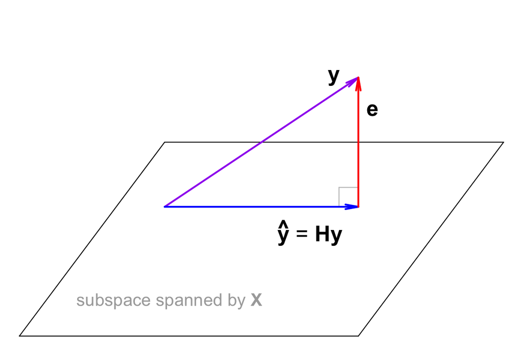

\(\mathbf{H}\) is called the “hat matrix” because it maps \(\mathbf{y}\) onto \(\hat{\mathbf{y}}\) (“y-hat”)

## Ordinary least squares

Consider for a moment what it means if

\[ \hat{\mathbf{y}} = \mathbf{X} (\mathbf{X}^{\top} \mathbf{X})^{-1} \mathbf{X}^{\top} \mathbf{y} \]

## Ordinary least squares

Consider for a moment what it means if

\[ \hat{\mathbf{y}} = \mathbf{X} (\mathbf{X}^{\top} \mathbf{X})^{-1} \mathbf{X}^{\top} \mathbf{y} \]

**We can estimate the data without any model parameters!**

## Independent & identically distributed

How do we know if our errors are IID?

- Knowledge of the problem/design
- Examine residual plots
- Tests of model fits

We will discuss this more in later lectures

## Ordinary least squares

What can we say about \(\hat{\boldsymbol{\beta}}\) when estimated this way?

1. It’s the *maximum likelihood estimate* (MLE)
2. It’s the *best linear unbiased estimate* (BLUE)

**NOTE**: these propoerties only hold if the errors (\(e_i\)) are *independent and identically distributed* (IID)

## Identifiability

Recall the solution for \(\hat{\boldsymbol{\beta}}\) where

\[ \hat{\boldsymbol{\beta}} = (\mathbf{X}^{\top} \mathbf{X})^{-1} \mathbf{X}^{\top} \mathbf{y} \]

If the quantity \(\mathbf{X}^{\top} \mathbf{X}\) is not invertible, then \(\hat{\boldsymbol{\beta}}\) is partially unidentifiable.

This occurs when the columns of \(\mathbf{X}\) are not independent  
(ie, \(\mathbf{X}\) is not of “full rank”)

## Lack of identifiability

### When does it arise?

- analysis of designed experiments (more later)
- two predictors are perfectly correlated (eg, temperature entered in both degrees F & degrees C)
- predictors are subsets of one another (eg, counts of trees in 3 categories: DBH \(\geq\) 10 cm, DBH \(\geq\) 20 cm, DBH \(\geq\) 30 cm)
- number of parameters equals or exceeds the observations  
  \(p = n\): model is *saturated*  
  \(p \geq n\): model is *supersaturated*